# Lab 3 - Regression Tree and Kaggle competition

## **Name and id:**

In this lab you will participate in a Kaggle competition:

https://www.kaggle.com/t/1552d52d5bbc474da5e024b385b9fe9e

In this competition you will train and test a **decision tree regressor** while choosing how to preprocess the data and model's parameters.

First, click the link and join the competition.

using 'kaggle.json' file from the first lab, load the competition's data:

(remember to upload it to your environment)

You suppose to have 3 files:

[output not shown]

```python
! mkdir ~/.kaggle
! cp kaggle.json ~/.kaggle/
! chmod 600 ~/.kaggle/kaggle.json
! kaggle competitions download -c decision-trees-lab-3-2023
! unzip decision-trees-lab-3-2023.zip
```

```
Downloading decision-trees-lab-3-2023.zip to /content
  0% 0.00/4.97M [00:00<?, ?B/s]
100% 4.97M/4.97M [00:00<00:00, 133MB/s]
Archive:  decision-trees-lab-3-2023.zip
  inflating: sample_submission.csv
  inflating: test_set.csv
  inflating: train_set.csv
```

## Task 1:

Load the train set and decide how to preprocess it.

Think about missing values, redundant features, categorical values, normalization ect.

```python
import pandas as pd

train_set = pd.read_csv('/content/train_set.csv', index_col='index')
train_set.head(10)
```

| index | airline | flight | source_city | departure_time | stops | arrival_time | destination_city | class | duration | days_left | price |
| --- | --- | --- | --- | --- | --- | --- | --- | --- | --- | --- | --- |
| 179791 | Vistara | UK-876 | Hyderabad | Night | one | Morning | Chennai | Economy | 14.25 | 41 | 6287 |
| 94264 | GO_FIRST | G8-116 | Bangalore | Early_Morning | one | Night | Mumbai | Economy | 13.83 | 3 | 5177 |
| 140559 | Vistara | UK-738 | Kolkata | Evening | one | Night | Bangalore | Economy | 25.67 | 36 | 8111 |
| 213532 | Air_India | AI-665 | Delhi | Early_Morning | one | Morning | Bangalore | Business | 27.17 | 21 | 42457 |
| 6230 | Indigo | 6E-2097 | Delhi | Early_Morning | one | Afternoon | Mumbai | Economy | 7.58 | 32 | 2410 |
| 24656 | Indigo | 6E-2043 | Delhi | Afternoon | one | Evening | Kolkata | Economy | 4.17 | 27 | 4257 |
| 208126 | Vistara | UK-879 | Delhi | Evening | one | Night | Mumbai | Business | 5.33 | 15 | 45156 |
| 43333 | Vistara | UK-771 | Mumbai | Early_Morning | one | Morning | Delhi | Economy | 26.58 | 3 | 14028 |
| 189185 | Air_India | AI-430 | Chennai | Morning | one | Evening | Mumbai | Economy | 8.08 | 15 | 10643 |
| 199118 | Vistara | UK-822 | Chennai | Morning | one | Night | Kolkata | Economy | 13.00 | 15 | 15384 |

```python
# implement here
train_set.info()
```

[output not shown]

```python
train_set.describe()
```

|  | duration | days_left | price |
| --- | --- | --- | --- |
| count | 210107.000000 | 210107.000000 | 210107.000000 |
| mean | 12.231815 | 25.996430 | 20941.685703 |
| std | 7.195575 | 13.577316 | 22717.531780 |
| min | 0.830000 | 1.000000 | 1105.000000 |
| 25% | 6.830000 | 14.000000 | 4784.000000 |
| 50% | 11.250000 | 26.000000 | 7439.000000 |
| 75% | 16.170000 | 38.000000 | 42521.000000 |
| max | 49.830000 | 49.000000 | 123071.000000 |

## Task 2:

Engineer features by combining 2 or more features in non linear way. For example multiply the number of stops and duration

Create 2 new features by combining existing features. Add those features to your feature set.

```python
import numpy as np
from sklearn.preprocessing import LabelEncoder
from collections import defaultdict

le = LabelEncoder()
# Encoding the variable
train_set = train_set.drop('flight', axis=1)
cat_cols = list(set(train_set.columns) - set(('duration','days_left','price')))
train_set[cat_cols] = train_set[cat_cols].apply(lambda col: le.fit_transform(col))
```

```python
# implement here
train_set["stops_duration"] = train_set["stops"] * train_set["duration"]
train_set["class_arrival_time"] = train_set["arrival_time"] * train_set['class']
```

```python
X = train_set.drop('price', axis= 1)
y = train_set['price']
```

```python
X
```

| index | airline | source_city | departure_time | stops | arrival_time | destination_city | class | duration | days_left | stops_duration | class_arrival_time |
| --- | --- | --- | --- | --- | --- | --- | --- | --- | --- | --- | --- |
| 179791 | 5 | 3 | 5 | 0 | 4 | 1 | 1 | 14.25 | 41 | 0.00 | 4 |
| 94264 | 2 | 0 | 1 | 0 | 5 | 5 | 1 | 13.83 | 3 | 0.00 | 5 |
| 140559 | 5 | 4 | 2 | 0 | 5 | 0 | 1 | 25.67 | 36 | 0.00 | 5 |
| 213532 | 1 | 2 | 1 | 0 | 4 | 0 | 0 | 27.17 | 21 | 0.00 | 0 |
| 6230 | 3 | 2 | 1 | 0 | 0 | 5 | 1 | 7.58 | 32 | 0.00 | 0 |
| ... | ... | ... | ... | ... | ... | ... | ... | ... | ... | ... | ... |
| 230202 | 5 | 5 | 0 | 1 | 5 | 0 | 0 | 8.17 | 4 | 8.17 | 0 |
| 211554 | 1 | 2 | 1 | 0 | 0 | 5 | 0 | 6.33 | 46 | 0.00 | 0 |
| 289662 | 5 | 1 | 1 | 0 | 2 | 2 | 0 | 9.75 | 37 | 0.00 | 0 |
| 261719 | 5 | 4 | 2 | 0 | 4 | 2 | 0 | 17.42 | 9 | 0.00 | 0 |
| 185042 | 4 | 1 | 1 | 2 | 4 | 2 | 1 | 2.67 | 34 | 5.34 | 4 |

210107 rows × 11 columns

## Task 3:

Create decision tree for regression using sklearn.tree.DecisionTreeRegressor library.

Select several parameters (such as: max_depth, ccp_alpha [etc.](https://scikit-learn.org/stable/modules/generated/sklearn.tree.DecisionTreeRegressor.html)) and tune them using [sklearn.model_selection.GridSearchCV](https://scikit-learn.org/stable/modules/generated/sklearn.model_selection.GridSearchCV.html)

Train the tree on the train set data.

```python
# implement here
from sklearn.model_selection import train_test_split
from sklearn.tree import DecisionTreeRegressor
from sklearn.model_selection import GridSearchCV


# "min_samples_split": [2,10,50,100,200,500],
# "min_samples_leaf": [2,10,50,100,200,500],
#               "max_leaf_nodes": [2,8,20,50,100,200,500],

X_train, X_test, y_train, y_test = train_test_split(X, y, test_size=0.2, random_state=34567)
algorithm = DecisionTreeRegressor(random_state=34567)
parameters = {
    "max_depth": [10,11],
              "max_features": [10,11],
              "ccp_alpha": [1e-05,1e-04,1e-06,1e-07,1e-08],
              "min_samples_split": [1,2,3,4,5],
              "max_leaf_nodes": [1300,1400,1500,1600,1700]}

clf = GridSearchCV(algorithm, parameters, cv= 5, scoring='neg_mean_absolute_error', n_jobs=-1)
clf.fit(X_train, y_train)
```

[output not shown]

[output not shown]

```python
clf.best_params_
```

[output not shown]

## Task 4:

Use the trained model to predict on the test set.

plot the selected tree using tree.plot_tree

Save the output predictions on a csv file to submit to the Kaggle competition. Name the file 'sample_submission', you have an example of it in a file named 'sample_submission.csv'

Make sure to keep the ids same as they are in "sample_submission.csv"

```python
# implement here
from sklearn.metrics import mean_absolute_error
best_model = clf.best_estimator_
y_pred = best_model.predict(X_test)
mean_absolute_error(np.array(y_test), y_pred)
```

```
2429.6306535396834
```

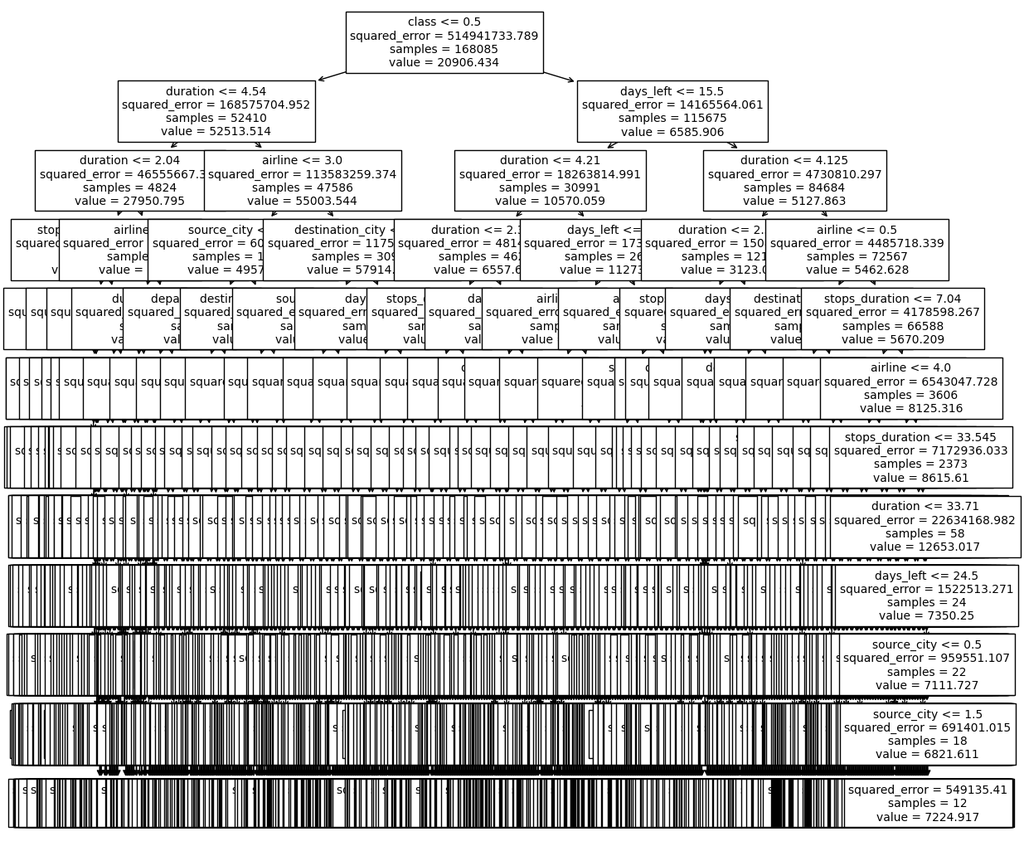

```python
from sklearn.tree import plot_tree
import matplotlib.pyplot as plt

column_names = X.columns
fig, ax = plt.subplots(figsize=(13, 13))
plot_tree(best_model, ax=ax, fontsize=10, feature_names=column_names)
plt.show()
```

```python
test_set = pd.read_csv('/content/test_set.csv', index_col='index')
test_set.head(10)
```

| index | airline | flight | source_city | departure_time | stops | arrival_time | destination_city | class | duration | days_left |
| --- | --- | --- | --- | --- | --- | --- | --- | --- | --- | --- |
| 156589 | AirAsia | I5-766 | Hyderabad | Night | one | Late_Night | Delhi | Economy | 4.25 | 35 |
| 224900 | Vistara | UK-963 | Delhi | Morning | one | Night | Chennai | Business | 14.25 | 48 |
| 87968 | Vistara | UK-810 | Bangalore | Early_Morning | zero | Morning | Delhi | Economy | 2.67 | 21 |
| 292192 | Air_India | AI-430 | Chennai | Morning | one | Evening | Mumbai | Business | 8.08 | 30 |
| 179722 | Indigo | 6.00E-157 | Hyderabad | Early_Morning | zero | Early_Morning | Chennai | Economy | 1.25 | 41 |
| 162867 | AirAsia | I5-974 | Hyderabad | Night | one | Early_Morning | Mumbai | Economy | 9.08 | 32 |
| 125361 | Indigo | 6E-7234 | Kolkata | Evening | one | Night | Delhi | Economy | 6.42 | 37 |
| 129449 | GO_FIRST | G8-102 | Kolkata | Afternoon | one | Night | Mumbai | Economy | 8.92 | 15 |
| 229213 | Vistara | UK-841 | Mumbai | Morning | one | Evening | Delhi | Business | 5.67 | 42 |
| 28197 | Vistara | UK-933 | Delhi | Afternoon | one | Morning | Kolkata | Economy | 18.17 | 46 |

```python
test_set = test_set.drop('flight', axis=1)
cat_cols = list(set(test_set.columns) - set(('duration','days_left','price')))
test_set[cat_cols] = test_set[cat_cols].apply(lambda col: le.fit_transform(col))
test_set["stops_duration"] = test_set["stops"] * test_set["duration"]
test_set["class_arrival_time"] = test_set["arrival_time"] * test_set['class']
```

```python
y_pred_test = best_model.predict(test_set)
test_set["price"] = y_pred_test
```

```python
test_set["price"]
```

```
index
156589     3003.600000
224900    55024.660530
87968      4519.131466
292192    50679.564470
179722     1684.388889
              ...
70584     14721.452381
199217     7265.521028
146676     4600.888889
135617    13272.300000
31100      5796.498212
Name: price, Length: 90046, dtype: float64
```

```python
from google.colab import files
test_set["price"].to_csv('sample_submission.csv')
files.download("sample_submission.csv")
```

## Task 5:

Convert the notebook into html:

1. Download the notebook by clicking the File tab
2. Upload it to this environment
3. Run the command:

```python
jupyter nbconvert --to html Lab3.ipynb
```